# Computation of the standardized precipitation evapotranspiration index (SPEI) using ERA5 reanalysis data

Fabio Gennaretti, Marc-André Lemay

Jaunary 28, 2025

# Objectives

In this document, you will learn how to:

- Use the `R` programming language to read and manipulate spatiotemporal data
- Compute and interpret the standardized precipitation evapotranspiration index (SPEI)
- Represent data graphically using the `ggplot2` package

This document is written in `R Markdown` format such that the text and code are intertwined. You will see the output of the code (console outputs and plots) appear in the document right after the code that produced it.

# Required packages

The following packages need to be installed and loaded for this analysis:

```r
library(terra) # Reading and processing of raster spatial data
library(sf) # Reading and processing of vector spatial data
library(SPEI) # Computation of the SPEI
library(lubridate) # Makes date-time objects easier to work with
```

```r
library(ggplot2) # Complex plots made easy with the grammar of graphics
library(parallel) # Parallel processing on multiple cores (not available on Windows)

# Setting the number of cores available for processing based on operating system
ncores <- if(.Platform$OS.type == "windows") 1 else 3
```

# Standardized precipitation evapotranspiration index (SPEI)

The [SPEI](https://spei.csic.es/) is an index that is used to detect and quantify droughts over multiple spatial and temporal scales (Vicente-Serrano, Beguerı́a, and López-Moreno 2010). Negative SPEI values indicate conditions that are drier than normal, whereas positive values indicate conditions that are wetter than normal. The SPEI can be computed over various time scales to detect droughts that last only a few days or weeks to droughts that last several years.

The SPEI is computed based on the difference between the water brought by precipitation and the water that was potentially taken away by evapotranspiration. The word “potentially” is important here: it is the potential for evapotranspiration that is more important than the evapotranspiration itself. Indeed, under drought conditions, it is likely for potential evapotranspiration to be higher than actual evapotranspiration because water sources have been exhausted.

The difference between daily precipitation and potential evapotranspiration is called the daily water balance. The `SPEI` package uses time series of daily water balance to transform them into a normalized index covering the time scale of interest. The normalization process involves comparison to daily water balance values at similar times of the year over several years. Computing SPEI therefore requires relatively long time series.

Here, we will calculate SPEI over the province of Quebec and analyze a three-week drought that occured at the end of August 2021 in western Quebec. We will look at the temporal trends of SPEI over the year 2021 and the spatial trends of SPEI over the province at the peak of the drought.

# Source data

Computing the SPEI requires precipitation data and potential evapotranspiration (PET) data at daily scale.

Here, precipitation data was obtained from the ERA5 reanalysis (Hersbach et al. 2020) through the [Climate Explorer](https://climexp.knmi.nl/select.cgi?id=someone@somewhere&field=era5_prcp_daily) web platform (Trouet and Van Oldenborgh 2013). The spatial resolution of the data is 0.5° (both in latitude and longitude) and the temporal resolution is daily. This data was subsetted to the spatial region (longitude -90° to -50° and latitude 40° to 65°) and time span (1981-2023) of interest. Precipitation data is represented in mm/day.

While several methods can be used to compute PET from various meteorological inputs, here we used [pre-computed PET data](https://data.bris.ac.uk/data/dataset/qb8ujazzda0s2aykkv0oq0ctp) at daily scale from published research (Singer et al. 2021) and always derived from ERA5 data. The original spatial resolution is 0.1°. I aggregated them to 0.5° in order to facilitate the lab (same spatial and temporal extent as the precipitation data). PET data is also represented in mm/day.

Surface temperature data is not necessary for computing SPEI (at least not directly), but for the sake of comparing August 2021 temperatures to historical temperatures for the same period, we also obtained surface temperature data from [Climate Explorer](https://climexp.knmi.nl/select.cgi?id=someone@somewhere&field=era5_t2m_daily) and subsetted it similarly to the precipitation and PET data. The temperature is represented in Kelvin.

All datasets are in the netCDF format (file extension .nc), which is commonly used to represent spatiotemporal meteorological data. Fortunately, you do not need to know anything about this format because the `terra` package seamlessly reads this format into raster objects that can be manipulated in `R`.

# Computing the SPEI at local site scale

We will first compute the SPEI at four locations of interest in the Abitibi-Témiscamingue region of Quebec, Canada. To do this, we need to get the precipitation and PET data into a `data.frame` with one row per day/location combination over the time period of interest. For that, we use the following function which leverages functionality form the `terra` (raster spatial data) and `sf` (vector spatial data) packages to extract meteorological data at specific points of interest.

```r
#' Format a netcdf dataset as a data.frame based on site locations
#'
#' This function needs a netcdf file (or really any file that can be
#' read using the terra package and has a time attribute) and an sf
#' object of point locations to extract the data for.
#'
#' @param filename A character, the name of the file containing the climate data
#' in netcdf format.
#' @param locations An sf object containing points denoting the locations to
#' extract the data for.
#' @param col_name A character, the name of the column to put the extracted
#' values into. Defaults to "variable".
#' @param agg A numeric value indicating the aggregation factor for the raster
#' If NULL (the default), then no aggregation is done. na.rm is set to TRUE for
#' aggregation.
#' @param site_col A character denoting the column containing the names of the
#' sites in the locations sf dataset. Optional: if NULL (the default), then the
#' output data.frame will not contain a "site" column.
#' @param time_range A length-two vector of dates in POSIXct format denoting
#' the first date (inclusive range) and last date (exclusive range) to use to
#' subset the input raster. Filtering is done based on the "time" arribute
#' of the raster.
#'
#' @return A data.frame with columns for the day, site and variable.
ncdf_to_df <- function(filename, locations, col_name = "variable",
                       agg = NULL, site_col = NULL, time_range = NULL) {

        # Reading the raster using the terra package
        rdata <- rast(filename)

        # Optionally filtering the raster layers based on time
        if(!is.null(time_range)) rdata <- rdata[[time(rdata) >= time_range[1] & time(rdata) < time_range[2]]]

        # Optionally aggregating the data
        # We need to preserve the time stamps
        if(!is.null(agg)) {
                times <- time(rdata)
                rdata <- aggregate(rdata, fact = agg, na.rm = TRUE)
                time(rdata) <- times
        }

        # Transforming the locations to the coordinate reference system of the raster and
        # using them to extract data
        locations <- st_transform(locations, st_crs(rdata))
        ldata <- t(as.matrix(extract(rdata, locations, ID = FALSE)))

        # Initializing the output data.frame
        output_df <- expand.grid(day = 1:nlyr(rdata),
                                 site = 1:nrow(locations))

        # Getting the data corresponding to that day and site by matrix indexing
        output_df[[col_name]] <- ldata[as.matrix(output_df)]

        # Getting the day in POSIXct format from the time attribute of the input raster
        output_df$day <- time(rdata)[output_df$day]

        # Optionally modifying the name of the site using the site_col column in the sf object
        if(!is.null(site_col)) output_df$site <- locations[output_df$site, ][[site_col]]

        output_df
}
```

We can now use our function to read the datasets and look at their structure. Here, we first extract data for four sites of interest on which we want to focus.

```r
# Read the data on the location of the study sites
sites <- st_read("../../data/sites/sites.shp", quiet = TRUE)

print(sites)
```

```
## Simple feature collection with 4 features and 4 fields
## Geometry type: POINT
## Dimension:     XY
## Bounding box:  xmin: -78.85814 ymin: 48.52893 xmax: -78.2142 ymax: 49.19511
## Geodetic CRS:  WGS 84
##   fid SITE      LAT      LONG                   geometry
## 1   1  BEC 48.77864 -78.40486 POINT (-78.40486 48.77864)
## 2   2  AMS 48.52893 -78.21420  POINT (-78.2142 48.52893)
## 3   3  AUC 49.15597 -78.80094 POINT (-78.80094 49.15597)
## 4   4  AUS 49.19511 -78.85814 POINT (-78.85814 49.19511)
```

```r
# Preparing the data.frame of precipitation data at the site (AMS, BEC, AUC, AUS) scale
site_precip <- ncdf_to_df("../../data/era5_data/era5_tp_daily_quebec.nc",
                          locations = sites,
                          col_name = "precip",
                          site_col = "SITE",
                          time_range = as.POSIXct(c("1981-01-01", "2024-01-01")))

str(site_precip)
```

```
## 'data.frame':    62820 obs. of  3 variables:
##  $ day   : Date, format: "1981-01-01" "1981-01-02" ...
##  $ site  : chr  "BEC" "BEC" "BEC" "BEC" ...
##  $ precip: num  0.129 3.0838 0.0181 1.1849 0.2016 ...
##  - attr(*, "out.attrs")=List of 2
##   ..$ dim     : Named int [1:2] 15705 4
##   .. ..- attr(*, "names")= chr [1:2] "day" "site"
##   ..$ dimnames:List of 2
##   .. ..$ day : chr [1:15705] "day=    1" "day=    2" "day=    3" "day=    4" ...
##   .. ..$ site: chr [1:4] "site=1" "site=2" "site=3" "site=4"
```

```r
# Preparing the data.frame of potential evapotranspiration data at the site scale
# The data is scattered across several files so we need to read them separately
site_pet <- ncdf_to_df("../../data/pet_data/daily_pet_quebec_combined.nc",
                                             locations = sites,
                                             col_name = "pet",
                                             site_col = "SITE")

str(site_pet)
```

```
## 'data.frame':    62820 obs. of  3 variables:
##  $ day : Date, format: "1981-01-01" "1981-01-02" ...
##  $ site: chr  "BEC" "BEC" "BEC" "BEC" ...
##  $ pet : num  0.1774 0.104 0.0276 0.1273 0.1352 ...
##  - attr(*, "out.attrs")=List of 2
##   ..$ dim     : Named int [1:2] 15705 4
##   .. ..- attr(*, "names")= chr [1:2] "day" "site"
##   ..$ dimnames:List of 2
##   .. ..$ day : chr [1:15705] "day=    1" "day=    2" "day=    3" "day=    4" ...
##   .. ..$ site: chr [1:4] "site=1" "site=2" "site=3" "site=4"
```

Now that we have read and formatted the precipitation and PET data, we can compute the daily water balance and the SPEI. The following function is a wrapper around the `spei` function of the `SPEI` package. It computes the daily water balance and formats the data for proper input to `spei`. It returns a `data.frame` similar to the input one, but to which a column called `"spei"` has been added with the SPEI of each day.

```r
#' Compute SPEI from data.frames of precipitation and potential evapotranspiration data
#'
#' This function computes the SPEI at a daily scale using input daily
#' precipitation and potential evapotranspiration data to compute the daily
#' water balance. The SPEI itself is computed using the spei function of the
#' SPEI package. The function will throw an error if any sites have a mix
#' of NA and non-NA values. However, if a given site has all NA values,
#' such as is the case for sites located over water bodies, then a value
#' of NA is returned for the SPEI at that site. This function also does not
#' use December 31 on leap years because the spei function needs all years
#' to have 365 days.
#'
#' @param precip_df A data.frame of precipitation data (in mm/day) such as
#' extracted using the ncdf_to_df function. Must contain a "precip" column for
#' the precipitation values.
#' @param pet_df A data.frame of potential evapotranspiration data (in mm/day)
#' such as extracted using the ncdf_to_df function. Must contain a "pet" column
#' for the potential evapotranspiration values.
#' @param start_year A numeric value indicating the first year for which
#' data are available.
#' @param scale A numeric value indicating the time window (in days) for
#' which the SPEI is to be computed. A time window of 7, for example, means
#' that the SPEI on a given day depends on the values of the past week.
#' @param ncores An integer indicating the number of cores to use for
#' SPEI computation. It effectively splits the SPEI computation at different
#' sites.
#'
#' @return A data.frame similar to the input ones with an added "spei" column
#' denoting the SPEI.
compute_spei <- function(precip_df, pet_df, start_year, scale, ncores = 3) {

        # Sanity checks
        stopifnot("precip" %in% colnames(precip_df))
        stopifnot("pet" %in% colnames(pet_df))

        # Sort the data by time and site name and check that the timestamps are the same
        pet_df <- pet_df[order(pet_df$site, pet_df$day), ]
        precip_df <- precip_df[order(precip_df$site, precip_df$day), ]
        stopifnot(all(precip_df$day == pet_df$day & precip_df$site == pet_df$site))

        # Computing the water balance (precipitation - potential evapotranspiration)
        precip_df$pet <- pet_df$pet
        precip_df$balance <- precip_df$precip - precip_df$pet

        # We remove December 31 on leap years because each year needs to have 365 days
        # for input to the spei function
        precip_df <- precip_df[!(leap_year(precip_df$day) &
                                 month(precip_df$day) == 12 &
                                 day(precip_df$day) == 31), ]

        stopifnot(nrow(precip_df) %% 365 == 0)

        # We compute the spei on each site separately using mclapply
        precip_df$spei <- unlist(mclapply(split(precip_df, precip_df$site), function(x) {
                                                  stopifnot(!is.unsorted(x$day))
                                                  if(all(is.na(x$balance))) return(rep(NA, nrow(x)))
                                                  balance_ts <- ts(x$balance, start = start_year, frequency = 365)
                                                  spei(data = balance_ts, scale = scale, verbose = FALSE)$fitted},
                                                  mc.cores = ncores))

        # Returning the data.frame with the added SPEI column
        precip_df
}
```

With this function, we can effectively compute the SPEI at the four sites of interest over the period 1981-2023. We use a `scale` parameter of 21 because we want to compute the SPEI over a three-week time scale. Therefore, every SPEI value will reflect the drought conditions over the previous three weeks.

```r
# Actually computing the SPEI at the site scale
site_spei <- compute_spei(precip_df = site_precip,
                          pet_df = site_pet,
                          start_year = 1981,
                          scale = 21,
                          ncores = ncores)

str(site_spei)
```

```
## 'data.frame':    62780 obs. of  6 variables:
##  $ day    : Date, format: "1981-01-01" "1981-01-02" ...
##  $ site   : chr  "AMS" "AMS" "AMS" "AMS" ...
##  $ precip : num  0.0445 2.8841 0.0182 0.9788 0.1763 ...
##  $ pet    : num  0.1649 0.1088 0.0275 0.1151 0.1317 ...
##  $ balance: num  -0.12046 2.77532 -0.00924 0.86371 0.04462 ...
##  $ spei   : num  NA NA NA NA NA NA NA NA NA NA ...
##  - attr(*, "out.attrs")=List of 2
##   ..$ dim     : Named int [1:2] 15705 4
##   .. ..- attr(*, "names")= chr [1:2] "day" "site"
##   ..$ dimnames:List of 2
##   .. ..$ day : chr [1:15705] "day=    1" "day=    2" "day=    3" "day=    4" ...
##   .. ..$ site: chr [1:4] "site=1" "site=2" "site=3" "site=4"
```

Let us look at the time series of SPEI over the year 2021. We can see that the SPEI reaches a minimum towards the end of August, which corresponds to the drought that we are interested in.

```r
# Looking at how extreme the end of August was within 2021
site_spei_2021 <- site_spei[year(site_spei$day) == 2021, ]

head(site_spei_2021[order(site_spei_2021$spei), ])
```

```
##              day site     precip      pet   balance      spei
## 14853 2021-08-31  BEC 0.11944771 2.361872 -2.242424 -2.461964
## 30558 2021-08-31  AMS 0.10108948 2.211536 -2.110446 -2.439630
## 14718 2021-04-18  BEC 0.13387203 3.282742 -3.148870 -2.373526
## 30423 2021-04-18  AMS 0.16582012 3.289040 -3.123220 -2.336917
## 30559 2021-09-01  AMS 0.02205372 2.663477 -2.641423 -2.319626
## 46263 2021-08-31  AUC 0.12207031 2.509472 -2.387402 -2.310554
```

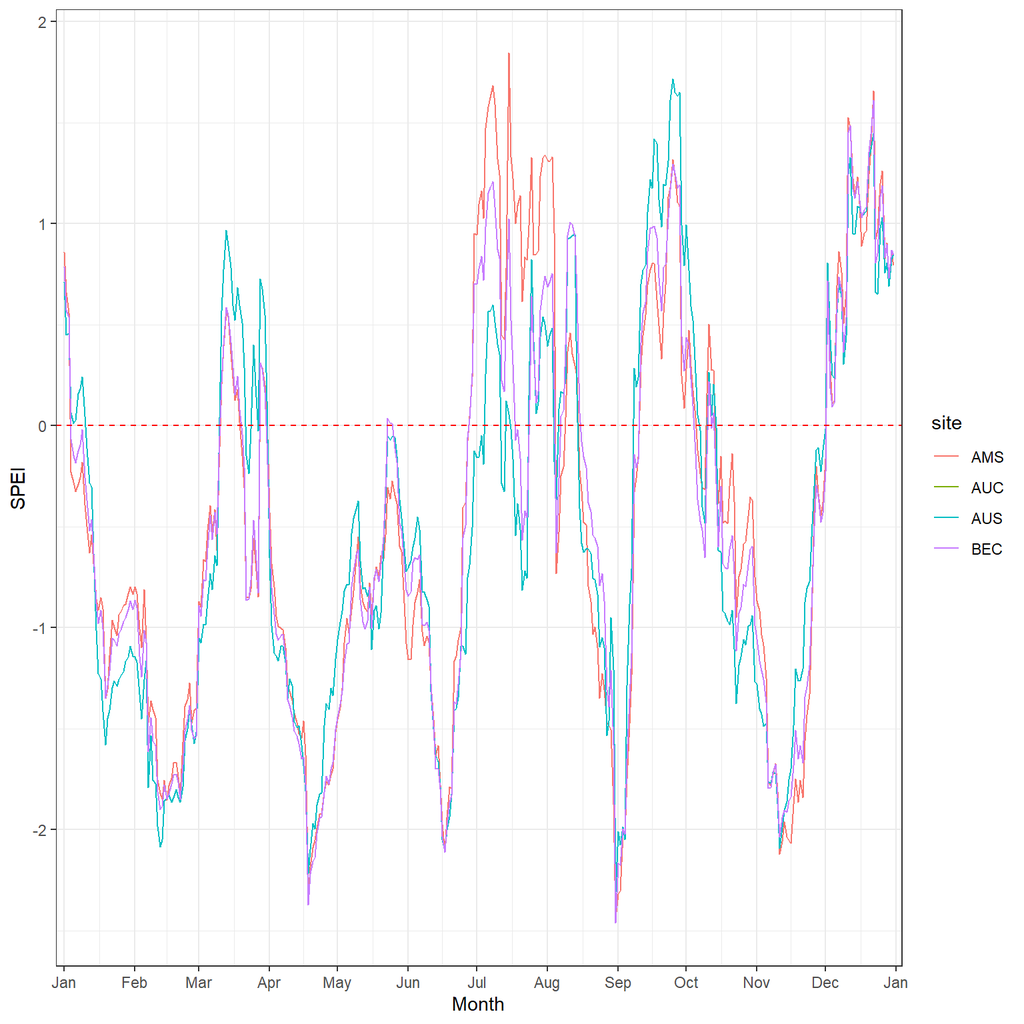

```r
site_spei_plot <- ggplot(site_spei_2021, aes(x = as.POSIXct(day), y = spei, color = site)) +
        geom_line() +
        # facet_wrap(~month(day, label = TRUE, abbr = FALSE), scales = "free_x") +
        geom_hline(yintercept = 0, color = "red", linetype = 2) +
        # scale_x_datetime(name = "Date", date_breaks = "7 days", date_labels = "%d", expand = c(0.01, 0.01)) +
        scale_x_datetime(name = "Month", date_breaks = "1 month", date_labels = "%b", expand = c(0.01, 0.01)) +
        ylab("SPEI") +
        theme_bw()

print(site_spei_plot)
```

# Computing the SPEI at regional scale

The time-series data at four sites of interest has shown that there was a drought going on in the study area towards the end of August 2021. We may also be interested to know how widespread that drought was at a regional scale.

The following code leverages the same functions as above to compute the SPEI over the whole area covered by the input datasets and not only at the four sites of interest. Because this is considerably more computationally intensive, we will compute SPEI over a reduced resolution of 2.5° instead of 0.5° as we did before.

```r
# Creating an sf object for the grid coordinates to extract the data
# The aggregation factor converts from 0.1-degree to 1-degree resolution
coord_rast <- aggregate(rast("../../data/pet_data/daily_pet_quebec_combined.nc"), fact = 5)

# We create a data.frame that is analogous to the one we used for sites before,
# except this time we have one point for every grid cell in the PET raster
coord_sf <- st_as_sf(as.data.frame(xyFromCell(coord_rast, 1:ncell(coord_rast))),
                     coords = c("x", "y"),
                     dim = "XY",
                     crs = st_crs(coord_rast))

coord_sf$SITE <- 1:nrow(coord_sf)

print(coord_sf)
```

```
## Simple feature collection with 160 features and 1 field
## Geometry type: POINT
## Dimension:     XY
## Bounding box:  xmin: -88.875 ymin: 41.375 xmax: -51.375 ymax: 63.875
## Geodetic CRS:  WGS 84
## First 10 features:
##                  geometry SITE
## 1  POINT (-88.875 63.875)    1
## 2  POINT (-86.375 63.875)    2
## 3  POINT (-83.875 63.875)    3
## 4  POINT (-81.375 63.875)    4
## 5  POINT (-78.875 63.875)    5
## 6  POINT (-76.375 63.875)    6
## 7  POINT (-73.875 63.875)    7
## 8  POINT (-71.375 63.875)    8
## 9  POINT (-68.875 63.875)    9
## 10 POINT (-66.375 63.875)   10
```

```r
# Reading the precipitation values at each of those points
# The agg argument converts from 0.5° to 1° resolution
map_precip <- ncdf_to_df("../../data/era5_data/era5_tp_daily_quebec.nc",
                         agg = 2,
                         locations = coord_sf,
                         col_name = "precip",
                         site_col = "SITE")

str(map_precip)
```

```
## 'data.frame':    2512800 obs. of  3 variables:
##  $ day   : Date, format: "1981-01-01" "1981-01-02" ...
##  $ site  : int  1 1 1 1 1 1 1 1 1 1 ...
##  $ precip: num  0.84 0.592 0.159 0.292 0.114 ...
##  - attr(*, "out.attrs")=List of 2
##   ..$ dim     : Named int [1:2] 15705 160
##   .. ..- attr(*, "names")= chr [1:2] "day" "site"
##   ..$ dimnames:List of 2
##   .. ..$ day : chr [1:15705] "day=    1" "day=    2" "day=    3" "day=    4" ...
##   .. ..$ site: chr [1:160] "site=  1" "site=  2" "site=  3" "site=  4" ...
```

```r
# Reading the pet data for preparing the map
map_pet <- ncdf_to_df("../../data/pet_data/daily_pet_quebec_combined.nc",
                         agg = 2,
                         locations = coord_sf,
                         col_name = "pet",
                         site_col = "SITE")

str(map_pet)
```

```
## 'data.frame':    2512800 obs. of  3 variables:
##  $ day : Date, format: "1981-01-01" "1981-01-02" ...
##  $ site: int  1 1 1 1 1 1 1 1 1 1 ...
##  $ pet : num  NA NA NA NA NA NA NA NA NA NA ...
##  - attr(*, "out.attrs")=List of 2
##   ..$ dim     : Named int [1:2] 15705 160
##   .. ..- attr(*, "names")= chr [1:2] "day" "site"
##   ..$ dimnames:List of 2
##   .. ..$ day : chr [1:15705] "day=    1" "day=    2" "day=    3" "day=    4" ...
##   .. ..$ site: chr [1:160] "site=  1" "site=  2" "site=  3" "site=  4" ...
```

```r
# Actually computing the SPEI from the combination of precipitation and potential evapotranspiration
map_spei <- compute_spei(precip_df = map_precip,
                         pet_df = map_pet,
                         start_year = 1981,
                         scale = 21,
                         ncores = ncores)

# This is a very large data.frame!
str(map_spei)
```

```
## 'data.frame':    2511200 obs. of  6 variables:
##  $ day    : Date, format: "1981-01-01" "1981-01-02" ...
##  $ site   : int  1 1 1 1 1 1 1 1 1 1 ...
##  $ precip : num  0.84 0.592 0.159 0.292 0.114 ...
##  $ pet    : num  NA NA NA NA NA NA NA NA NA NA ...
##  $ balance: num  NA NA NA NA NA NA NA NA NA NA ...
##  $ spei   : num  NA NA NA NA NA NA NA NA NA NA ...
##  - attr(*, "out.attrs")=List of 2
##   ..$ dim     : Named int [1:2] 15705 160
##   .. ..- attr(*, "names")= chr [1:2] "day" "site"
##   ..$ dimnames:List of 2
##   .. ..$ day : chr [1:15705] "day=    1" "day=    2" "day=    3" "day=    4" ...
##   .. ..$ site: chr [1:160] "site=  1" "site=  2" "site=  3" "site=  4" ...
```

Because we are particularly interested in SPEI values for August 31, we now extract the values for that day specifically and format them as a raster. At this point, the raster could be exported to a file (for example in .tiff format) or could be kept in memory for further processing. For this document, we will use it for plotting the data.

```r
# Extracting the data only for the 21-day period ending on August 31, 2021
spei_august31 <- map_spei[year(map_spei$day) == 2021 & month(map_spei$day) == 8 & day(map_spei$day) == 31, ]

# Converting this dataset to a raster
spei_raster <- as.data.frame(st_coordinates(coord_sf))
stopifnot(all.equal(spei_august31$site, coord_sf$SITE))
spei_raster$spei <- spei_august31$spei

# The rast function has a method to convert from data.frame to raster
# provided that we meet certain formatting requirements
spei_raster <- rast(spei_raster)

# We need to set the coordinate reference system of the newly created raster
crs(spei_raster) <- crs(coord_sf)

# Let us check if everything looks fine
print(spei_raster)
```

```
## class       : SpatRaster
## dimensions  : 10, 16, 1  (nrow, ncol, nlyr)
## resolution  : 2.5, 2.5  (x, y)
## extent      : -90.125, -50.125, 40.125, 65.125  (xmin, xmax, ymin, ymax)
## coord. ref. : lon/lat WGS 84
## source(s)   : memory
## name        :      spei
## min value   : -2.620769
## max value   :  2.082036
```

# Plotting SPEI and climate anomalies at regional scale

Now that we have formatted the SPEI data as a raster, it is easy to plot it using functionality from the `terra` package.

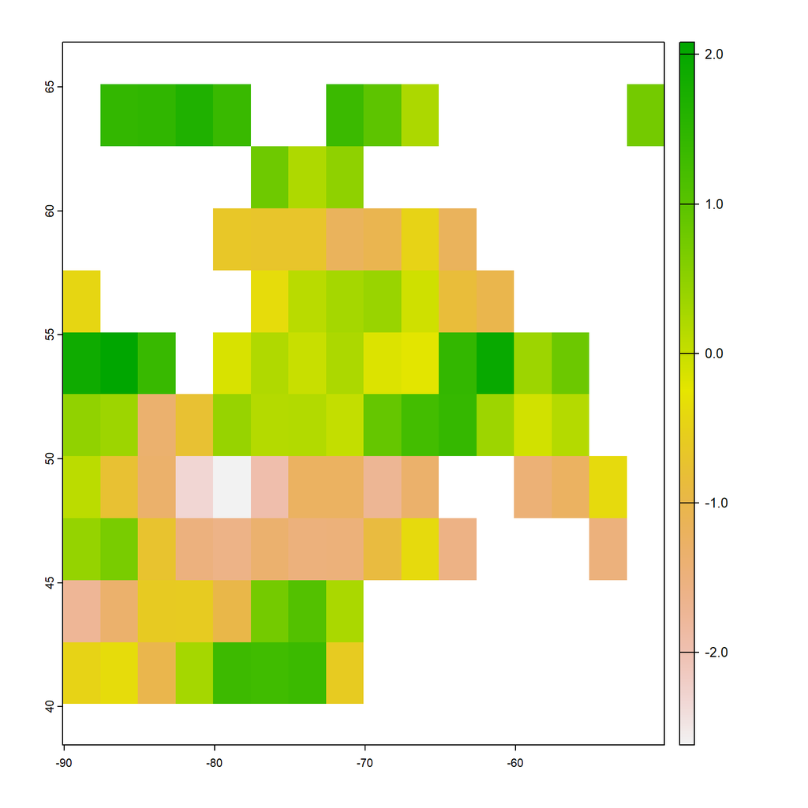

```r
plot(spei_raster)
```

However, that map does not quite meet all our needs. In particular, we would like to add a world map outline and be able to add the location of our sites on the map. This is particularly useful if we want to produce maps for communicating our results with a wider audience. This following function provides functionality for doing exactly that using `ggplot2` functions to extract world map data and plot our raster and point data.

```r
#' Produce an anomaly plot from a raster
#'
#' This function takes a raster and formats it for plotting using
#' ggplot2 against a world map background.
#'
#' @param dataset Raster data (in longitude/latitude coordinates) to use for
#' plotting. Must have already been computed as anomalies as no post-processing
#' of the data is done other than formatting.
#' @param scale_name A character string to use as the name of the color scale.
#' @param point_coordinates A data.frame of point coordinates to use
#' for plotting the locations of the study sites.
#'
#' @return A ggplot object representing a complete anomaly plot with color
#' scale/legend.
anomaly_plot <- function(dataset, scale_name, point_coordinates) {

        # Re-formatting the raster as a data.frame for plotting
        anomalies <- as.data.frame(xyFromCell(dataset, 1:ncell(dataset)))
        anomalies$value <- extract(dataset, as.matrix(anomalies))[[1]]
        names(anomalies) <- c("longitude", "latitude", "value")

        # Remove the NA values because otherwise they appear gray
        anomalies <- anomalies[!is.na(anomalies$value), ]

        # Getting the world map from ggplot
        world_map <- map_data("world")

        ggplot(world_map, aes(x = long, y = lat)) +
                geom_polygon(aes(group = group), fill = "gray", color = "black") +
                geom_tile(data = anomalies, aes(x = longitude, y = latitude, fill = value), alpha = 0.8) +
                scale_fill_gradient2(name = scale_name, low = "blue", mid = "white", high = "red") +
                coord_cartesian(xlim = c(-90, -50), ylim = c(40, 65), expand = FALSE) +
                geom_point(data = point_coordinates, aes(x = x, y = y), size = 0.8) +
                geom_text(data = point_coordinates, aes(x = x + 0.5, y = y + 0.5, label = label), hjust = 0) +
                scale_x_continuous(name = "Longitude") +
                scale_y_continuous(name = "Latitude") +
                theme_bw() +
                theme(axis.text = element_text(color = "black"),
                      axis.ticks = element_line(color = "black"),
                      panel.grid = element_blank(),
                      legend.key.width = unit(0.1, "in"))
}
```

We can use this function to display our SPEI data along with site coordinates:

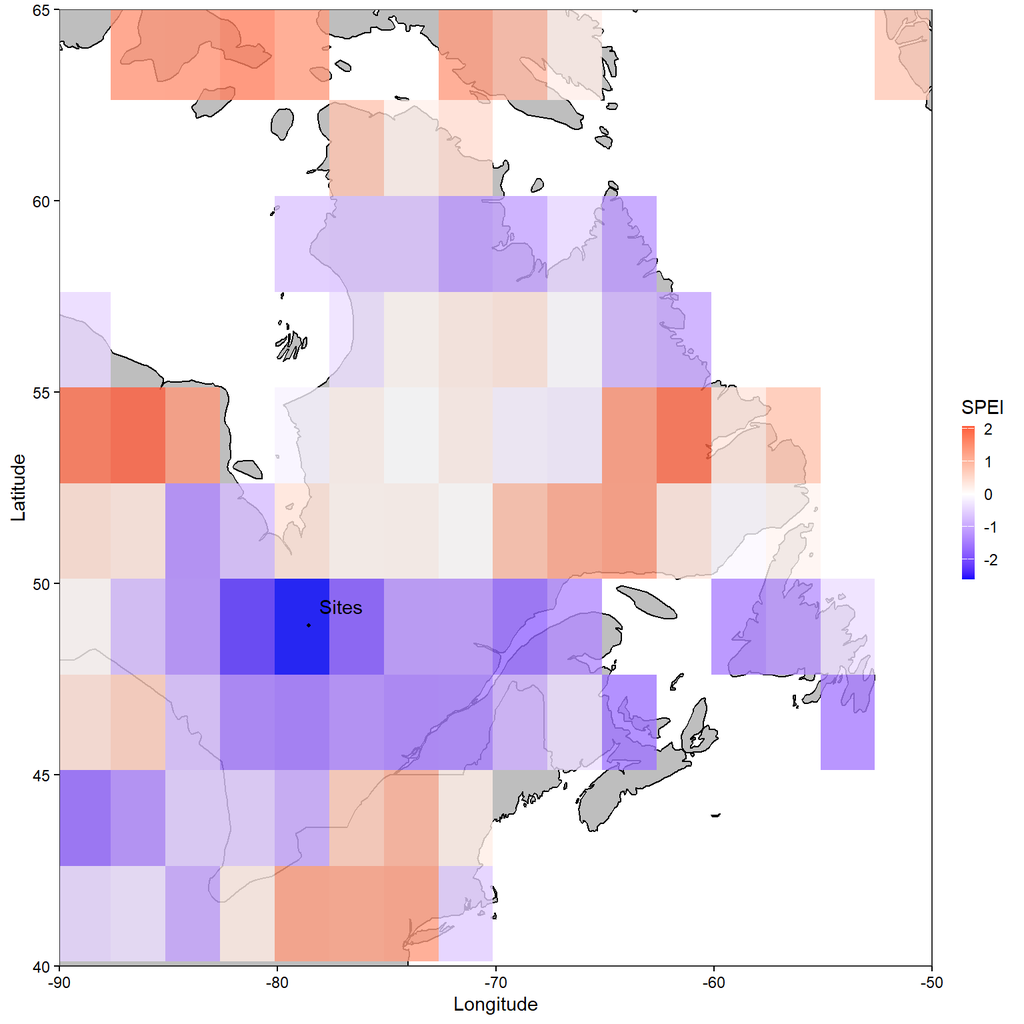

```r
spei_plot <- anomaly_plot(dataset = spei_raster,
                          point_coordinates = data.frame(x = -78.56954, y = 48.91466, label = "Sites"),
                          scale_name = "SPEI")

print(spei_plot)
```

While the SPEI contains information about the water balance, it would be interesting to also look at the anomalies in temperature and precipitation to disentangle the contribution of these two variables. To do this, we will use the following function that computes anomalies (differences between a particular value and the average over some time period) for a given input variable. The function will compare the period from August 11 to 31 2021 to the same time period for the years 1981-2023 (except 2021 which is left out).

```r
#' Compute anomalies from a raster time-series
#'
#' Using a time-series of raster data, computes the anomaly of August 11-31,
#' 2021 compared to the same time period for all other years. At the moment
#' these dates are hard-coded but this could be made a user-controllable
#' parameter if needed.
#'
#' @param filename A character, the name of a file containing the raster
#' time-series.
#' @param agg A numeric value, the aggregation factor to use in computing
#' the anomalies. If NULL (the default), no aggregation is done.
#'
#' @return A raster with similar x/y dimensions as the input with the anomalies
#' for the period considered (drought period minus same period in other years).
compute_anomalies <- function(filename, agg = NULL) {
        # Reading the dataset
        dataset <- rast(filename)

        # Optionally aggregating the dataset while preserving timestamps
        if(!is.null(agg)) {
                times <- time(dataset)
                dataset <- aggregate(dataset, fact = agg)
                time(dataset) <- times
        }

        # Determining which tiles are part of the drought period
        # August 11 to 31, 2024
        drought_tiles <- time(dataset) >= as.POSIXct("2021-08-11", format = "%Y-%m-%d") &
                time(dataset) < as.POSIXct("2021-09-01", format = "%Y-%m-%d")

        # Determining which tiles correspond to the reference period
        # August 11 to 31 of all years BUT 2021
        reference_tiles <- month(time(dataset)) == 8 & day(time(dataset)) %in% 11:31
        reference_tiles <- xor(drought_tiles, reference_tiles)

        # Computing the anomalies by subtracting the historical average from the average over the drought
        anomalies <- mean(dataset[[drought_tiles]]) - mean(dataset[[reference_tiles]])

        anomalies
}
```

We can now use the functions `compute_anomalies` and `anomaly_plot` together to plot the temperature and precipitation anomalies. As we can see, temperature was unusually high and precipitation was unusually low over the period of interest in our study area. Therefore, both factors contributed to the drought conditions that are reflected in the SPEI values.

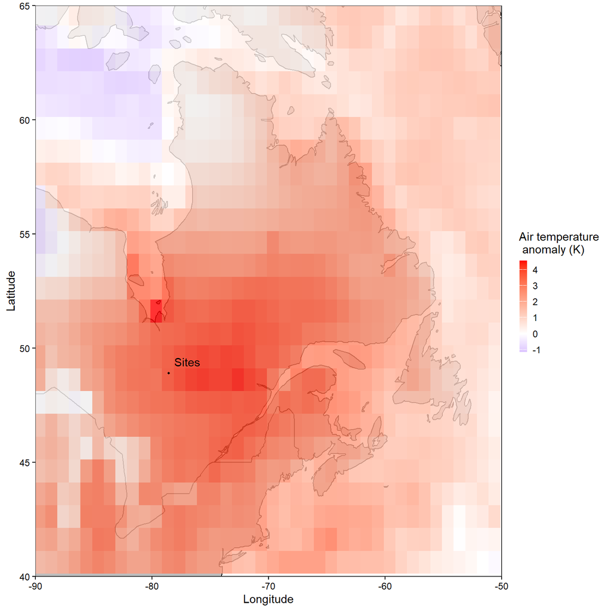

```r
# Preparing the anomalies of temperature and precipitation
temp <- compute_anomalies("../../data/era5_data/era5_t2m_daily_quebec.nc", agg = 2)
prec <- compute_anomalies("../../data/era5_data/era5_tp_daily_quebec.nc", agg = 2)

temp_plot <- anomaly_plot(dataset = temp,
                          point_coordinates = data.frame(x = -78.56954, y = 48.91466, label = "Sites"),
                          scale_name = "Air temperature\n anomaly (K)")

print(temp_plot)
```

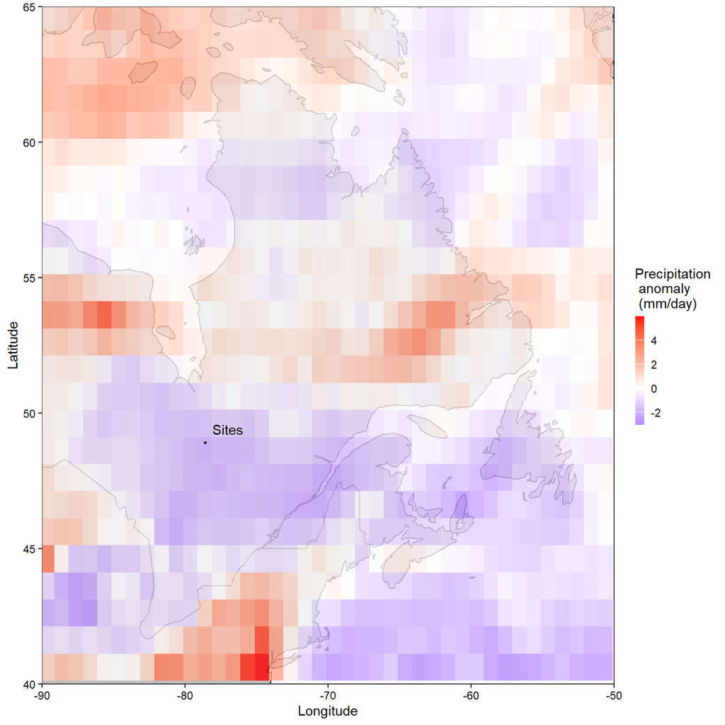

```r
prec_plot <- anomaly_plot(dataset = prec,
                          point_coordinates = data.frame(x = -78.56954, y = 48.91466, label = "Sites"),
                          scale_name = "Precipitation\n anomaly\n (mm/day)")

print(prec_plot)
```

# References

Hersbach, Hans, Bill Bell, Paul Berrisford, Shoji Hirahara, András Horányi, Joaquı́n Muñoz-Sabater, Julien Nicolas, et al. 2020. “The ERA5 Global Reanalysis.” *Quarterly Journal of the Royal Meteorological Society* 146 (730): 1999–2049.

Singer, Michael Bliss, Dagmawi Teklu Asfaw, Rafael Rosolem, Mark O Cuthbert, Diego G Miralles, David MacLeod, Edisson Andres Quichimbo, and Katerina Michaelides. 2021. “Hourly Potential Evapotranspiration at 0.1 Resolution for the Global Land Surface from 1981-Present.” *Scientific Data* 8 (1): 224.

Trouet, Valerie, and Geert Jan Van Oldenborgh. 2013. “KNMI Climate Explorer: A Web-Based Research Tool for High-Resolution Paleoclimatology.” *Tree-Ring Research* 69 (1): 3–13.

Vicente-Serrano, Sergio M, Santiago Beguerı́a, and Juan I López-Moreno. 2010. “A Multiscalar Drought Index Sensitive to Global Warming: The Standardized Precipitation Evapotranspiration Index.” *Journal of Climate* 23 (7): 1696–1718.